# Introduction to `adept` package

Marta Karas

2019-02-02

# Intro

`adept` package implements ADaptive Empirical Pattern Transformation (ADEPT) ([1]) **method for pattern segmentation from a time-series `x`**. ADEPT was designed for optimal use in performing fast, accurate walking strides segmentation from high-density data collected from a wearable accelerometer worn during continuous walking activity.

This vignette intends to introduce a reader to the ADEPT method and demonstrate the usage of the `segmentPattern` function which implements ADEPT method. Here, we focus on illustrating `segmentPattern` functionality via simulated data examples; see the *Walking strides segmentation with `adept`"* vignette ([2]) for an example of walking stride segmentation from subsecond accelerometry data with `adept` package.

# ADEPT method

ADEPT identifies pattern occurrences from a time-series `x` via maximizing similarity (correlation, covariance etc.) between time-series `x` windows and a pattern template(s). It accounts for a possible presence of variation in both (1) pattern occurrence duration time and (2) shape over time:

1. Consider an example in which a pattern occurrence is changing, possibly multiple times, its duration time within a time-series `x`. To address such scenario, **ADEPT considers various scales of a pattern template(s)** to allow for obtaining the higher similarity between a time-series `x` and a template.
2. Consider an example in which an event we aim to segment takes more than one distinct pattern shape within time-series `x`. To address such scenario, **multiple pattern templates are allowed simultaneously** in the ADEPT method.

## Pattern template

Here, a pattern template is thought of as a numeric vector that represents the pattern of interest. In practice, a pattern template may be derived based on some pre-segmented small part of the data.

- See [1] where we show a way to derive walking stride templates from subsecond accelerometry data collected from sensors worn at left wrist, left hip and both ankles.
- See [2] for an example of employing walking stride templates derived in [1] to segment pattern from a separate, publicly available subsecond-level accelerometry data.

In this vignette, for the purpose of the presentation, a pattern template(s) will be a simulated data vector(s).

# Install and load `adept` package

If not installed yet, install `adept` package from GitHub (`devtools` package needs to be installed to do it).

```r
# install.packages("devtools")       ## for installing packages from GitHub repository
devtools::install_github("martakarass/adept")
```

Load `adept`.

```r
library(adept)
library(magrittr)
library(ggplot2)
```

# Pattern segmentation with `adept` package

The examples below are organized into suites.

- Suites are characterized by some specific data generation setting, for example: *Examples 1: signals simulated with no noise, same-length pattern*.
- Examples are intended to illustrate `segmentPattern` functionality, including effect of the function’s parameter usage, for example: *Example 1(b): simple segmentation, modify `pattern.dur.seq` argument*.

## Examples 1: signals simulated with no noise, same length of all pattern occurences

### Simulate data

Simulate data:

- no noise in a simulated time-series `x`,
- all simulated pattern occurrences of the same length (vector length: `101`).

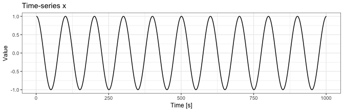

```r
## Generate signal and pattern template
x0 <- cos(seq(0, 2 * pi * 10, length.out = 1001))
x  <- x0
template <- x0[1:101]

## Plot time-series `x`
data.frame(x = 1:length(x), y = x) %>%
  ggplot() + geom_line(aes(x = x, y = y)) +  theme_bw(base_size = 9) +
  labs(x = "Time [s]", y = "Value", title = "Time-series x")
```

Plot pattern template. We shall use `template` object in the segmentation algorithm.

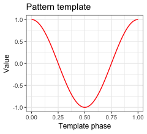

```r
data.frame(x = seq(0, 1, length.out = 101), y = template) %>%
  ggplot() + geom_line(aes(x = x, y = y), color = "red") +
  theme_bw(base_size = 9) + labs(x = "Template phase", y = "Value", title = "Pattern template")
```

### Example 1(a): run simple segmentation

Use `segmentPattern` function to identify pattern occurrences within a time-series `x`.

```r
pattern.dur.seq <- c(90, 100, 110)
out <- segmentPattern(x = x,
                      x.fs = 1,
                      template = template,
                      pattern.dur.seq = pattern.dur.seq,
                      similarity.measure = "cor",
                      compute.template.idx = TRUE)
out
```

[output not shown]

#### Segmentation output explained

Each row of the output data frame (here: `out` object above) summarizes information about one identified pattern occurrence:

- `tau_i` - pattern occurrence start, expressed as an index of a time-series `x`,
- `T_i` - pattern occurrence duration, expressed in a time-series `x` vector length,
- `sim_i` - value of similarity statistic (here: correlation) between a pattern template and corresponding window of a time-series `x` (see Details in `segmentPattern` documentation),
- `template_i` - index of a pattern template corresponding to an identified pattern occurrence, or `NA` if `compute.template.idx = FALSE` is used (see Details in `segmentPattern` documentation); here: we provided only one distinct pattern template, hence all `template_i`’s are equal 1.

### Example 1(b): use `pattern.dur.seq` argument to modify a grid of pattern duration

Similarly, we aim to 3identify pattern occurrences within a time-series `x`, but this time we include the true pattern duration time `101` in a grid of considered pattern durations (`pattern.dur.seq`).

We shall see that `sim_i` - a value of similarity statistic (here: correlation) - is now equal to `1` for each identified pattern occurrence. In other words, a perfect match between a time-series `x` and a template was obtained. It is possible because:

- the simulated time-series `x` has no noise,
- we used a true (gold-standard) pattern template (`template`),
- we used true pattern duration time `101` in a grid of considered pattern durations (`pattern.dur.seq`).

```r
pattern.dur.seq <- 90:110  ## assume dense pattern duration grid ranging 90-110 seconds
out <- segmentPattern(x = x,
                      x.fs = 1,  ## assume data frequency 1 observation per second
                      template = template,
                      pattern.dur.seq = pattern.dur.seq,
                      similarity.measure = "cor",
                      compute.template.idx = TRUE)
out
```

```
#>    tau_i T_i sim_i template_i
#> 1      1 101     1          1
#> 2    101 101     1          1
#> 3    201 101     1          1
#> 4    301 101     1          1
#> 5    401 101     1          1
#> 6    501 101     1          1
#> 7    601 101     1          1
#> 8    701 101     1          1
#> 9    801 101     1          1
#> 10   901 101     1          1
```

### Example 1(c): use `x.fs` argument to modify assumed frequency at which a time-series `x` is collected

The below example demostrates usage of `x.fs` parameter. We shall see that if we:

- modify `x.fs` - assumed frequency at which a time-series `x` is collected, expressed in a number of observations per second,
- adjust accordingly `pattern.dur.seq` - assumed grid of pattern duration times used in segmentation, expressed in seconds,

then the segmentation results stay the same as in *Example 1(b)*.

```r
pattern.dur.seq <- 90:110 * 0.01   ## assume pattern duration grid ranging 0.9-1.1 seconds
out <- segmentPattern(x = x,
                      x.fs = 100,   ## assume data frequency 100 observations per second
                      template = template,
                      pattern.dur.seq = pattern.dur.seq,
                      similarity.measure = "cor",
                      compute.template.idx = TRUE)
out
```

```
#>    tau_i T_i sim_i template_i
#> 1      1 101     1          1
#> 2    101 101     1          1
#> 3    201 101     1          1
#> 4    301 101     1          1
#> 5    401 101     1          1
#> 6    501 101     1          1
#> 7    601 101     1          1
#> 8    701 101     1          1
#> 9    801 101     1          1
#> 10   901 101     1          1
```

## Examples 2: signals simulated with no noise, length of pattern occurences varies

### Simulate data

Simulate data:

- no noise in a simulated time-series `x`,
- length of simulated pattern occurences varies (their vector length ranges between `60` and `120`.

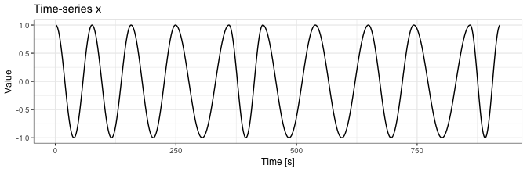

```r
## Generate signal and pattern template
## Grid of true pattern occurence durations
set.seed(1)
s.grid <- sample(60:120, size = 10)
## True pattern assumed in data generation process
true.pattern <- cos(seq(0, 2 * pi, length.out = 200))

## Generate a time-series x that consists of "glued" pattern occurrences
## of different length
x <- numeric()
for (s.tmp in s.grid){
  true.pattern.s <- approx(seq(0, 1, length.out = 200),
                            true.pattern,
                            xout = seq(0, 1, length.out = s.tmp))$y
  if (length(x) > 0){
    x <- c(x, true.pattern.s[-1])
  } else {
    x <- c(x, true.pattern.s)
  }
}

## Define template
template <- true.pattern

## Plot time-series `x`
data.frame(x = 1:length(x), y = x) %>%
  ggplot() + geom_line(aes(x = x, y = y)) +  theme_bw(base_size = 9) +
  labs(x = "Time [s]", y = "Value", title = "Time-series x")
```

Plot pattern template (it is the same as in *Examples 1*).

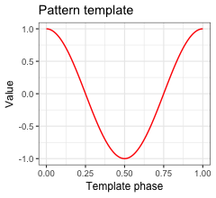

```r
data.frame(x = seq(0, 1, length.out = length(template)), y = template) %>%
  ggplot() + geom_line(aes(x = x, y = y), color = "red") +
  theme_bw(base_size = 9) + labs(x = "Template phase", y = "Value", title = "Pattern template")
```

```r
## Function to plot segmentation results in a fancy way with ggplot2
library(ggplot2)
out.plot1 <- function(val, out){

  yrange <- c(-1, 1) * max(abs(val))
  y.h <- 0
  plt <- ggplot()
  for (i in 1:nrow(out)){
    tau1_i <- out[i, "tau_i"]
    tau2_i <- tau1_i + out[i, "T_i"] - 1
    plt <-
      plt +
      geom_vline(xintercept = tau1_i, color = "red") +
      geom_vline(xintercept = tau2_i, color = "red") +
      annotate(
        "rect",
        fill = "pink",
        alpha = 0.3,
        xmin = tau1_i,
        xmax = tau2_i,
        ymin = yrange[1],
        ymax = yrange[2]
    )
  }
  plt <-
    plt +
    geom_line(data = data.frame(x = 1:length(val), y = val),
              aes(x = x, y = y),
              color = "black",
              size = 0.3) +
    theme_bw(base_size = 9) +
    labs(x = "Time [s]", y = "Black line: x",
         title = "Black line: signal x\nRed vertical lines: start and end points of identified pattern occurrence\nRed shaded area: area corresponding to identified pattern occurrence")
  plot(plt)
}
```

### Example 2(a): run simple segmentation

By using a dense grid of duration of pattern occurrences (`pattern.dur.seq`), we shall obtain a perfect match between time-series `x` and a template rescaled to various scale parameters. Hence, in the segmentation results plot below, one can see that the start and end points of an individual identified pattern occurrence, marked with red vertical lines, do overlap.

```r
pattern.dur.seq <- 60:120
out <- segmentPattern(x = x,
                      x.fs = 1,
                      template = template,
                      pattern.dur.seq = pattern.dur.seq,
                      similarity.measure = "cor",
                      compute.template.idx = TRUE)
out
```

```
#>    tau_i T_i sim_i template_i
#> 1      1  76     1          1
#> 2     76  82     1          1
#> 3    157  93     1          1
#> 4    249 112     1          1
#> 5    360  71     1          1
#> 6    430 110     1          1
#> 7    539 111     1          1
#> 8    649  95     1          1
#> 9    743 118     1          1
#> 10   860  63     1          1
```

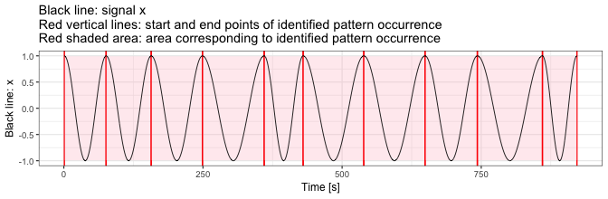

```r
## Plot segmetation results
out.plot1(x, out)
```

### Example 2(b): run simple segmentation with less dense grid of assumed duration of pattern occurrences

In this example we employ a less dense grid of assumed duration of pattern occurrences (`pattern.dur.seq`). As a result, we no longer see a perfect match between a time-series `x` and a template; we shall see that `sim_i` values are not all equal to `1` and we do see a lack of overlap between the start and end points of an individual identified pattern occurrence, as marked with red vertical lines.

- The reason to consider a less dense `pattern.dur.seq` grid of assumed duration of pattern occurrence in segmentation is a shorter computational time.
- We will see later that when *peak detection tuning procedure* is employed, having a “maximally dense” grid is not necesairly needed.

```r
pattern.dur.seq <- c(60, 90, 120)
out <- segmentPattern(x = x,
                      x.fs = 1,
                      template = template,
                      pattern.dur.seq = pattern.dur.seq,
                      similarity.measure = "cor",
                      compute.template.idx = TRUE)
out
```

```
#>    tau_i T_i     sim_i template_i
#> 1      9  60 0.9913537          1
#> 2     87  60 0.9875419          1
#> 3    159  90 0.9991040          1
#> 4    260  90 0.9925351          1
#> 5    366  60 0.9933033          1
#> 6    425 120 0.9967502          1
#> 7    549  90 0.9923207          1
#> 8    651  90 0.9986598          1
#> 9    742 120 0.9999117          1
#> 10   861  60 0.9979972          1
```

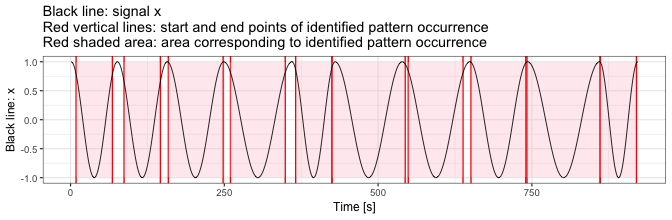

```r
out.plot1(x, out)
```

### Example 2(c): use `similarity.measure` argument to use covariance as similarity statistic

Similar as above, but here we use covariance as a similarity measure statistic. We shall observe that `sim_i` values in the result data frame change and the segmentation results change slightly (explanation: a change of similarity statistic values may affect ADEPT iterative maximization procedure results).

```r
pattern.dur.seq <- c(60, 90, 120)
out <- segmentPattern(x = x,
                      x.fs = 1,
                      template = template,
                      pattern.dur.seq = pattern.dur.seq,
                      similarity.measure = "cov",  ## use covariance as a similarity measure statistic
                      compute.template.idx = TRUE)
out
```

```
#>    tau_i T_i     sim_i template_i
#> 1      9  60 0.5918631          1
#> 2     72  90 0.7339804          1
#> 3    174  60 0.4559175          1
#> 4    245 120 0.7289255          1
#> 5    366  60 0.6348018          1
#> 6    440  90 0.6108531          1
#> 7    534 120 0.7306629          1
#> 8    653  90 0.6897910          1
#> 9    742 120 0.7182487          1
#> 10   861  60 0.6989475          1
```

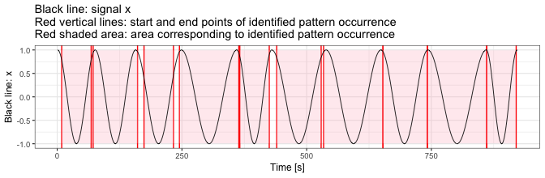

```r
out.plot1(x, out)
```

## Examples 3: signals simulated with no noise, length of pattern occurences and pattern shape vary

### Simulate data

Simulate data:

- no noise in simulated time-series `x`,
- length of simulated pattern occurrences varies (vector length ranges between `60` and `120`),
- two different true pattern shapes within a time-series `x`.

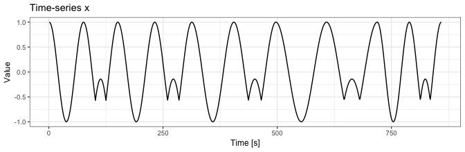

```r
# Grid of different true pattern occurence durations
set.seed(1)
s.grid <- sample(60:120, size = 5)
true.pattern.1 <- cos(seq(0, 2 * pi, length.out = 200))
true.pattern.2 <- true.pattern.1
seq.tmp <- 70:130
true.pattern.2[seq.tmp] <- 2 * true.pattern.2[min(seq.tmp)] + abs(true.pattern.2[seq.tmp])

## Generate signal x that consists of "glued" pattern occurrences of different length
x <- numeric()
for (ss in s.grid){
  ## Add a part from from true.pattern.1
  true.pattern.1.s <- approx(seq(0, 1, length.out = 200),
                             true.pattern.1,
                             xout = seq(0, 1, length.out = ss))$y
  if (length(x) > 0){
    x <- c(x, true.pattern.1.s[-1])
  } else {
    x <- c(x, true.pattern.1.s)
  }
  ## Add a part from from true.pattern.2
  true.pattern.2.s <- approx(seq(0, 1, length.out = 200),
                             true.pattern.2,
                             xout = seq(0, 1, length.out = ss))$y
  x <- c(x, true.pattern.2.s[-1])
}

## Plot time-series `x`
data.frame(x = 1:length(x), y = x) %>%
  ggplot() + geom_line(aes(x = x, y = y)) +  theme_bw(base_size = 9) +
  labs(x = "Time [s]", y = "Value", title = "Time-series x")
```

Plot two vectors that were used in the data generation process as the true patterns.

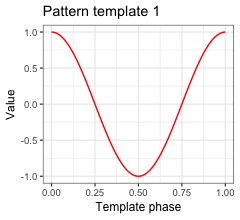

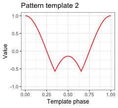

```r
plt1 <-
  data.frame(x = seq(0, 1, length.out = length(true.pattern.1)), y = true.pattern.1) %>%
  ggplot() + geom_line(aes(x = x, y = y), color = "red") +
  theme_bw(base_size = 9) + labs(x = "Template phase", y = "Value", title = "Pattern template 1") +
  scale_y_continuous(limits = c(-1,1))
plt2 <-
  data.frame(x = seq(0, 1, length.out = length(true.pattern.2)), y = true.pattern.2) %>%
  ggplot() + geom_line(aes(x = x, y = y), color = "red") +
  theme_bw(base_size = 9) + labs(x = "Template phase", y = "Value", title = "Pattern template 2") +
  scale_y_continuous(limits = c(-1,1))
plt1;plt2
```

### Example 3(a): run simple segmentation

We use a dense grid of duration of pattern occurrences (`pattern.dur.seq`). We firstly use a template consisting of only one “true” pattern. We shall see that:

- first and every other subsequent pattern occurrence identified has corresponding correlation `sim_i` equal to `1`; these pattern occurrences were generated with the use of a pattern template `true.pattern.1` we supplied to the segmentation algorithm,
- second and every other subsequent pattern occurrence identified has corresponding correlation `sim_i` smaller than `1`; these pattern occurrences were generated with the use of a pattern template `true.pattern.2` we did not supply to the segmentation algorithm.

```r
pattern.dur.seq <- 60:120
template <- true.pattern.1

out <- segmentPattern(x = x,
                      x.fs = 1,
                      template = template,
                      pattern.dur.seq = pattern.dur.seq,
                      similarity.measure = "cor",
                      compute.template.idx = TRUE)
out
```

```
#>    tau_i T_i     sim_i template_i
#> 1      1  76 1.0000000          1
#> 2     76  76 0.9288369          1
#> 3    151  82 1.0000000          1
#> 4    232  82 0.9288407          1
#> 5    313  93 1.0000000          1
#> 6    405  93 0.9286870          1
#> 7    497 112 1.0000000          1
#> 8    608 112 0.9285767          1
#> 9    719  71 1.0000000          1
#> 10   789  71 0.9292973          1
```

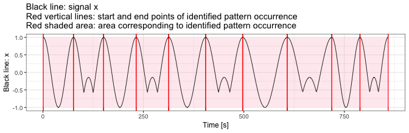

```r
## Plot segmetation results
out.plot1(x, out)
```

### Example 3(b): use `similarity.measure.thresh` argument to set a threshold of minimal similarity value

```r
pattern.dur.seq <- 60:120
template <- true.pattern.1

out <- segmentPattern(x = x,
                      x.fs = 1,
                      template = template,
                      pattern.dur.seq = pattern.dur.seq,
                      similarity.measure = "cor",
                      similarity.measure.thresh = 0.95,
                      compute.template.idx = TRUE)
out
```

```
#>   tau_i T_i sim_i template_i
#> 1     1  76     1          1
#> 2   151  82     1          1
#> 3   313  93     1          1
#> 4   497 112     1          1
#> 5   719  71     1          1
```

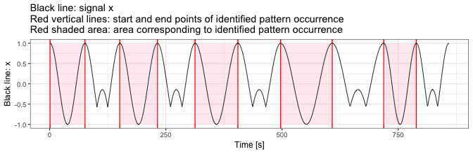

```r
## Plot segmetation results
out.plot1(x, out)
```

### Example 3(c): use multiple distinct pattern templates

Similarly as above, but now we use two distinct pattern templates in the `template` argument. As expected, now we see that every pattern occurrence identified has corresponding correlation `sim_i` equal to `1`. It is because these pattern occurrences were generated with the use of either a pattern template `true.pattern.1` or `true.pattern.2`, and we supplied *both* of them to the segmentation algorithm.

The column `template_i` in a returned data frame shall show numbers `1` and `2` iterchangeably; the number is an indicator of pattern template that yielded particular identified pattern occurrence (see `segmentPattern` documentation manual for details).

```r
pattern.dur.seq <- 60:120
template <- list(true.pattern.1,
                 true.pattern.2)

out <- segmentPattern(x = x,
                      x.fs = 1,
                      template = template,
                      pattern.dur.seq = pattern.dur.seq,
                      similarity.measure = "cor",
                      compute.template.idx = TRUE)
out
```

```
#>    tau_i T_i sim_i template_i
#> 1      1  76     1          1
#> 2     76  76     1          2
#> 3    151  82     1          1
#> 4    232  82     1          2
#> 5    313  93     1          1
#> 6    405  93     1          2
#> 7    497 112     1          1
#> 8    608 112     1          2
#> 9    719  71     1          1
#> 10   789  71     1          2
```

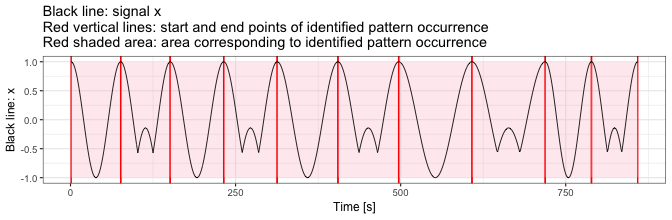

```r
## Plot segmetation results
out.plot1(x, out)
```

## Examples 4: signals simulated with noise, length of pattern occurences and pattern shape vary

### Simulate data

Simulate data:

- add noise to a simulated time-series `x` (noise added is supposed to “hide” the pattern occurrences),
- length of simulated pattern occurrences varies (vector length ranges between `60` and `120`),
- two different true pattern shapes within a time-series `x`.

Here, we re-use signal `x` from data generated above in *Examples 3*.

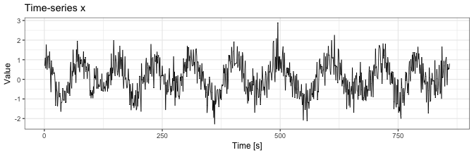

```r
## Add noise to a  signal `x` from data generated in *Examples 3*.
set.seed(1)
x2 <- x + rnorm(length(x), sd = 0.5)

## Plot time-series `x`
data.frame(x = 1:length(x2), y = x2) %>%
  ggplot() + geom_line(aes(x = x, y = y), size = 0.3) +  theme_bw(base_size = 9) +
  labs(x = "Time [s]", y = "Value", title = "Time-series x")
```

### Example 4(a): run simple segmentation

We use two distinct pattern templates, as used in data generation.

```r
pattern.dur.seq <- 60:120
template <- list(true.pattern.1,
                 true.pattern.2)

out <- segmentPattern(x = x2,
                      x.fs = 1,
                      template = template,
                      pattern.dur.seq = pattern.dur.seq,
                      similarity.measure = "cor",
                      compute.template.idx = TRUE)
out
```

```
#>    tau_i T_i     sim_i template_i
#> 1      2  72 0.8535560          1
#> 2     76  78 0.7624407          2
#> 3    156  75 0.7818015          1
#> 4    234  72 0.6939557          2
#> 5    305 109 0.8512611          1
#> 6    413  75 0.6190537          2
#> 7    497 109 0.8228649          1
#> 8    608 108 0.7349471          2
#> 9    717  76 0.8293969          1
#> 10   792  61 0.5502773          2
```

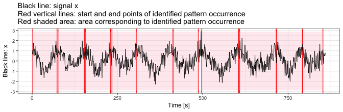

```r
## Plot segmetation results
out.plot1(x2, out)
```

### Example 4(b): use `x.adept.ma.W` argument to smooth time-series `x` for similartity matrix computation purpose

One may consider using a smoothed version of a time-series `x` for the purposes of computing similarity between a time-series `x` and pattern template(s). To do this, the argument `x.adept.ma.W` is used to define a length of a window used in moving average smoothing of a time-series `x`; `W` is expressed in seconds. The default is `NULL` (no smoothing applied).

**Smoothing of a time-series `x`**

To get a sense what `W` should be used as a length of a window used in moving average smoothing, one may use `windowSmooth` function to experiment with different values.

- Here, `W = 10` seems like a plausible choice, that is, the smoothed signal seems to be stripped out of much of a noise but still preserve the underlying pattern.

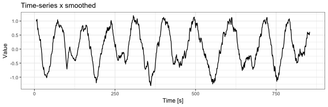

```r
x2.smoothed <- windowSmooth(x = x2, x.fs = 1, W = 10)

data.frame(x = 1:length(x2.smoothed), y = x2.smoothed) %>%
  ggplot() + geom_line(aes(x = x, y = y)) +  theme_bw(base_size = 9) +
  labs(x = "Time [s]", y = "Value", title = "Time-series x smoothed")
```

We shall see that compared to the *Example 4(a)*, the effect of using a smoothed version of a time-series `x` in similarity matrix computation is pronounced in `sim_i` values in the resulted data frame as well as in a slight change in `tau_i` and `T_i` values.

```r
out <- segmentPattern(x = x2,
                      x.fs = 1,
                      template = template,
                      pattern.dur.seq = pattern.dur.seq,
                      similarity.measure = "cor",
                      x.adept.ma.W = 10,
                      compute.template.idx = TRUE)
out
```

```
#>    tau_i T_i     sim_i template_i
#> 1      4  69 0.9935740          1
#> 2     76  79 0.9607909          2
#> 3    158  70 0.9831188          1
#> 4    233  78 0.9818980          2
#> 5    312  95 0.9823877          1
#> 6    406  88 0.9510599          2
#> 7    495 114 0.9821003          1
#> 8    608 111 0.9879948          2
#> 9    718  72 0.9942539          1
#> 10   790  66 0.9398574          2
```

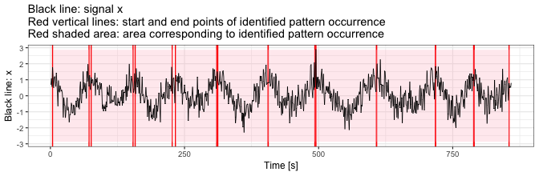

```r
## Plot segmetation results
out.plot1(x2, out)
```

### Example 4(c): use `finetune`, `finetune.maxima.nbh.W` arguments to employ “maxima” fine-tune procedure

We continue to use the segmentation setting similar to the one we used above in *Example 4(b)*, but this time we employ a fine-tuning procedure of stride locations.

**“maxima” fine-tune procedure**

“maxima” fine-tune procedure tunes preliminarily identified locations of parttern occurence beginning and end so as they correspond to local maxima of time-series `x` (or smoothed version of `x`, as we shall see later) found within neighbourhoods of preliminary locations.

The parameter `finetune.maxima.nbh.W` defines a length of the two neighborhoods centered at preliminarily identified pattern occurrence beginning and end points within which we search for local maxima. (see `segmentPattern` documentation for more details).

We shall see from the plot of segmentation results below that almost all identified pattern occurrence start / end points are hitting the time point our eyes identify as “local signal maxima”.

- Possibly the only exception is around time point `600`; that comes from the restriction we imposed on the pattern duration times by setting `pattern.dur.seq <- 60:120`, that is, the pattern occurrence cannot be longer than `120`.

```r
out <- segmentPattern(x = x2,
                      x.fs = 1,
                      template = template,
                      pattern.dur.seq = pattern.dur.seq,
                      similarity.measure = "cor",
                      x.adept.ma.W = 10,
                      finetune = "maxima",
                      finetune.maxima.nbh.W = 30,
                      compute.template.idx = TRUE)
out
```

```
#>    tau_i T_i     sim_i template_i
#> 1      4  67 0.9935740          1
#> 2     70  78 0.9123034          2
#> 3    147  80 0.9831188          1
#> 4    226  78 0.9327744          2
#> 5    303 100 0.9823877          1
#> 6    402  94 0.9559945          2
#> 7    495 115 0.9823238          1
#> 8    615 104 0.9879948          2
#> 9    718  75 0.9942539          1
#> 10   792  61 0.9373485          2
```

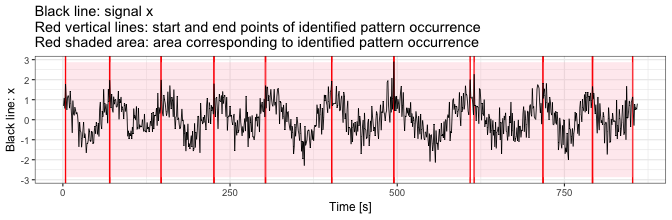

```r
## Plot segmetation results
out.plot1(x2, out)
```

### Example 4(d): use `finetune`, `finetune.maxima.ma.W`, `finetune.maxima.nbh.W` arguments to employ “maxima” fine-tune procedure and smooth signal for peak detection

One other step that can be made in “maxima” fine-tune procedure is to use a smoothed version of a signal for peak detection. Here, we smooth a time-series `x` for *both* similarity matrix computation procedure and for “maxima” fine-tune procedure.

We would typically choose a more aggressive smoothing for a “maxima” fine-tune procedure (as defined via smoothing window length `finetune.maxima.ma.W`) than for similarity matrix computation (as defined via smoothing window length `x.adept.ma.W`); the reason is that often an aggressive smoothing is needed to remove (“smooth together”) multiple local maxima of a time-series `x`.

We again use `windowSmooth` function to experiment with different values of a window length in moving average smoothing.

- Here, `W = 50` seems like a plausible choice as it removes (“smooth together”) multiple local maxima of a time-series `x`, leaving out a single one.

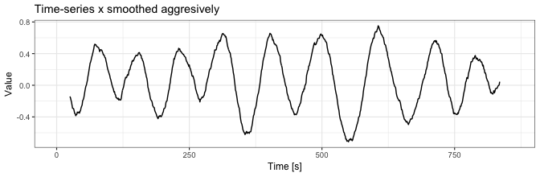

```r
x2.smoothed <- windowSmooth(x = x2, x.fs = 1, W = 50)

data.frame(x = 1:length(x2.smoothed), y = x2.smoothed) %>%
  ggplot() + geom_line(aes(x = x, y = y)) +  theme_bw(base_size = 9) +
  labs(x = "Time [s]", y = "Value", title = "Time-series x smoothed aggresively")
```

```r
pattern.dur.seq <- 60:120
template <- list(true.pattern.1,
                 true.pattern.2)

out <- segmentPattern(x = x2,
          x.fs = 1,
          template = template,
          pattern.dur.seq = pattern.dur.seq,
          similarity.measure = "cor",
          x.adept.ma.W = 10,  ## smoothing parameter for similarity matrix computation
          finetune = "maxima",  ## use fine-tuning
          finetune.maxima.ma.W = 50, ## smoothing parameter for peak detection in fine-tuning
          finetune.maxima.nbh.W = 30,  ## neighborhoods length in fine-tuning
          compute.template.idx = TRUE)
out
```

```
#>    tau_i T_i     sim_i template_i
#> 1      1  72 0.9935740          1
#> 2     72  85 0.9607909          2
#> 3    156  75 0.9831188          1
#> 4    230  84 0.9818980          2
#> 5    313  90 0.9823877          1
#> 6    402  97 0.9627633          1
#> 7    498 109 0.9815284          1
#> 8    606 110 0.9828041          2
#> 9    715  75 0.9942539          1
#> 10   789  60 0.9398574          2
```

The plot below shows the segmentation results

```r
## Function to plot nice results visualization
out.plot2 <- function(val, val.sm, out){
  yrange <- c(-1, 1) * max(abs(val))
  y.h <- 0
  plt <-
    ggplot() +
    geom_line(data = data.frame(x = 1:length(val), y = val),
              aes(x = x, y = y),
              color = "grey")
  for (i in 1:nrow(out)){
    tau1_i <- out[i, "tau_i"]
    tau2_i <- tau1_i + out[i, "T_i"] - 1
    plt <-
      plt +
      geom_vline(xintercept = tau1_i, color = "red") +
      geom_vline(xintercept = tau2_i, color = "red") +
      annotate(
        "rect",
        fill = "pink",
        alpha = 0.3,
        xmin = tau1_i,
        xmax = tau2_i,
        ymin = yrange[1],
        ymax = yrange[2]
    )
  }
  plt <-
    plt +
    geom_line(data = data.frame(x = 1:length(val.sm), y = val.sm),
              aes(x = x, y = y),
              color = "black", size = 0.6, alpha = 0.8) +
    theme_bw(base_size = 9) +
    labs(x = "Time [s]",
         y = "Black line: smoothed x",
         title ="Light gray line: signal x\nBlack line: smoothed signal x\nRed vertical lines: start and end points of identified pattern occurrence\nRed shaded area: area corresponding to identified pattern occurrence")
  plot(plt)
}
```

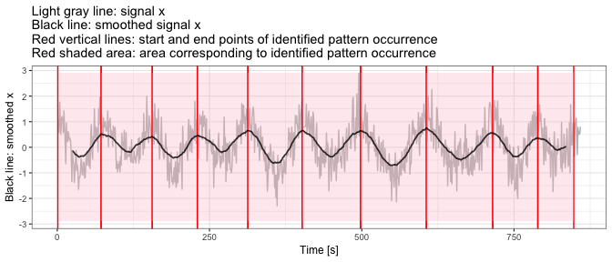

```r
## Plot segmetation results
out.plot2(x2, windowSmooth(x = x2, x.fs = 1, W = 50), out)
```

# References

References:

1: Karas, M., Straczkiewicz, M., Fadel, W., Harezlak, J., Crainiceanu, C., Urbanek, J.K. *Adaptive empirical pattern transformation (ADEPT) with application to walking stride segmentation*, Submitted to *Biostatistics*, 2018.

2: Karas, M. *Walking strides segmentation with `adept`* package vignette.